# Stack Overflow Analysis

## Years of Professional Coding vs Total salary per year

In this analysis, we aim to understand the relationship between years of professional coding and total salary per year. The process will be conducted in three main steps: data cleaning, data transformation, and data visualization.

**Step 1: Data Cleaning**

```r
# Select relevant columns and remove missing values
ProExpVsSalary <- MyData %>%
  select(YearsCodePro, Currency, CompTotal) %>%
  na.omit()

# Extract currency abbreviations and split the data by currency
ProExpVsSalary <- ProExpVsSalary %>%
  mutate(abbreviation = str_extract(Currency, "\\b[A-Z]{3}\\b"))

# Split data into different datasets by currency
currency_datasets <- split(ProExpVsSalary, ProExpVsSalary$abbreviation)
```

**Step 2: Data Transformation**

```r
# Define a function to convert variables to numeric and remove outliers
process_dataset <- function(dataset) {
  dataset$YearsCodePro <- as.numeric(dataset$YearsCodePro)
  dataset$CompTotal <- as.numeric(dataset$CompTotal)
  Q1 <- quantile(dataset$CompTotal, 0.25)
  Q3 <- quantile(dataset$CompTotal, 0.75)
  IQR <- Q3 - Q1
  dataset <-
    subset(dataset, CompTotal > (Q1 - 1.5 * IQR) &
             CompTotal < (Q3 + 1.5 * IQR))
  return(dataset)
}

# Apply the process_dataset function to each currency dataset
euro_dataset <- process_dataset(currency_datasets$EUR)
usd_dataset <- process_dataset(currency_datasets$USD)
gbp_dataset <- process_dataset(currency_datasets$GBP)
jpy_dataset <- process_dataset(currency_datasets$JPY)
cny_dataset <- process_dataset(currency_datasets$CNY)
```

**Step 3: Data Visualization**

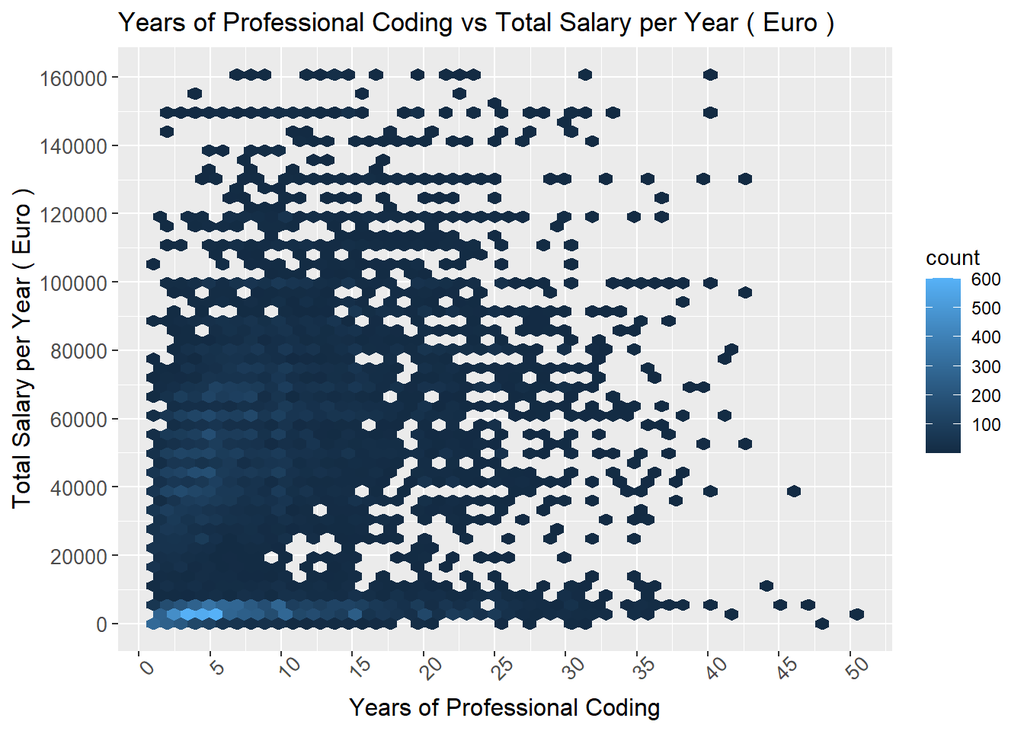

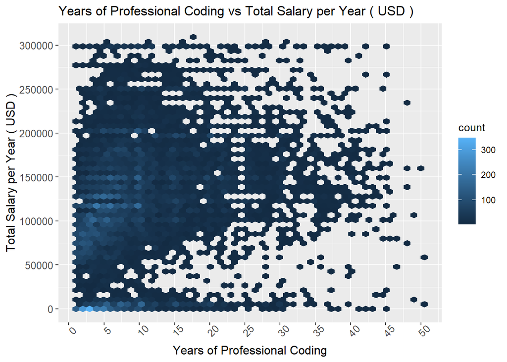

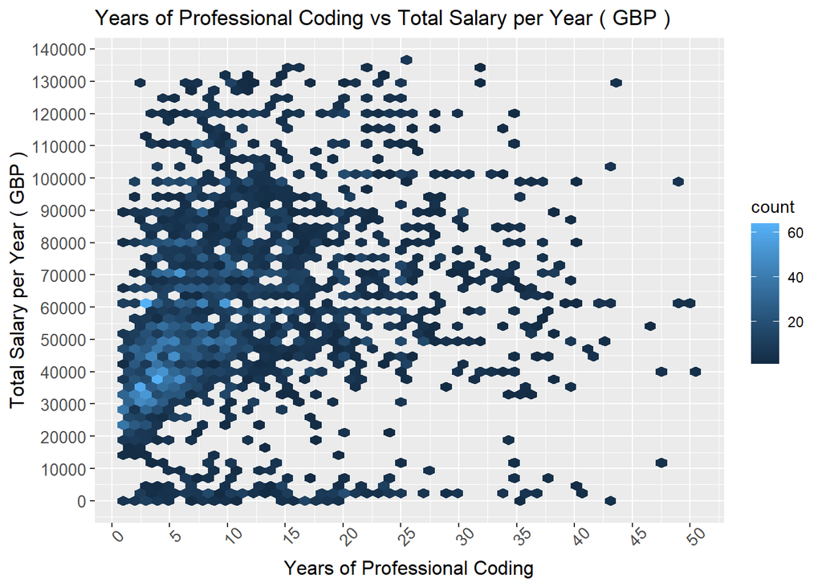

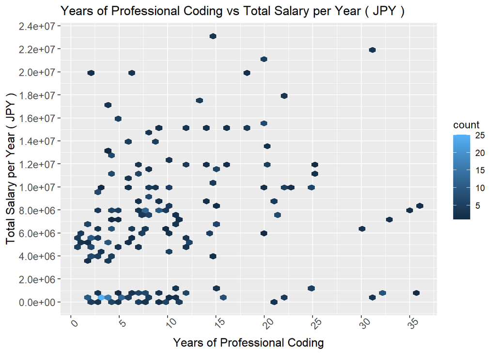

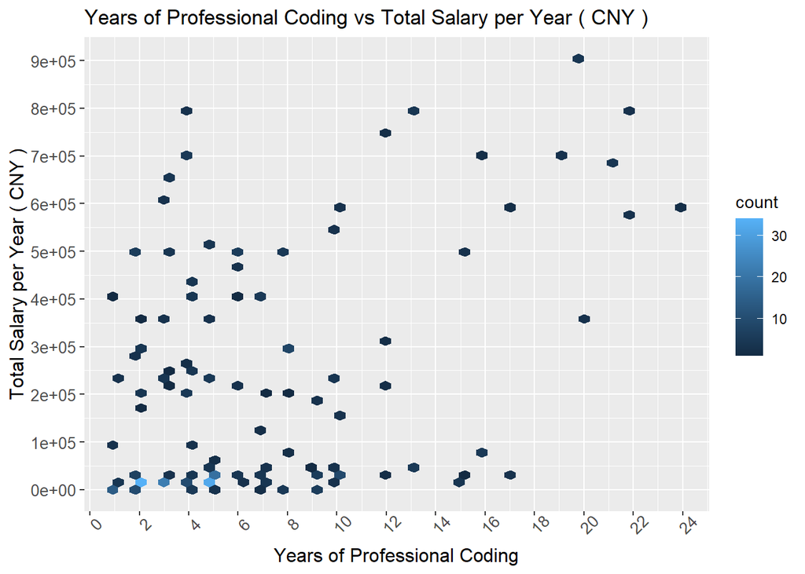

In the first step, we select necessary columns and remove missing values. Then we split the dataset by currency. In the second step, we convert variables to numeric and remove outliers from each currency-specific dataset. Lastly, we create hexbin plots for each dataset to visualize the relationship between years of professional coding and total salary per year for each currency.

## Conclusion

The comprehensive analysis performed on the dataset provided several insightful findings related to the software industry.

Firstly, we found that the top programming languages being used were Javascript, HTML and SQL and those desired to be learned by developers were Javascript, Python and TypeScript. This indicates a shift in trend towards Python and Typescript wanted to learned more. We can also notice that Javascript is the top language still in both language people know and language people want to know. That’s a useful insight. These insights can guide aspiring coders to focus their learning and for organizations to make strategic decisions about adopting newer languages.

Secondly, we observed that Remote work was the most prevalent mode of work among developers. This suggests that after COVID, remote work has solidified itself and more workers than ever are doing remote work.

Our analysis of educational backgrounds revealed that a bachelor degree was the most common among developers. This suggest that even though most of the developers have a bachelor degree, coding and learning how to code in general can come in any shape or form.

These insights collectively provide a holistic understanding of the developer landscape. They can guide various stakeholders such as students, developers, educators, and organizations in making informed decisions.

Overall, the data provides a rich foundation for further exploration and offers a wealth of insights about the current state of the software industry.